# Временные ряды

## неделя 6

Глазунов А.В.

Загрузим библиотеки

```python
from google.colab import drive
drive.mount('/content/gdrive',force_remount=True)
```

```
Go to this URL in a browser: https://accounts.google.com/o/oauth2/auth?client_id=947318989803-6bn6qk8qdgf4n4g3pfee6491hc0brc4i.apps.googleusercontent.com&redirect_uri=urn%3aietf%3awg%3aoauth%3a2.0%3aoob&response_type=code&scope=email%20https%3a%2f%2fwww.googleapis.com%2fauth%2fdocs.test%20https%3a%2…

Enter your authorization code:
··········
```

```python
cd /content/gdrive/'My Drive'/Colab_Notebooks/ML_c6_TAXI
```

```
/content/gdrive/My Drive/Colab_Notebooks/ML_c6_TAXI
```

```python
PATH_TO_DATA = 'data'
```

```python
pip install category_encoders
```

```
     |████████████████████████████████| 81kB 2.6MB/s
```

```python
pip install frozendict
```

```python
import warnings
warnings.filterwarnings('ignore')


from sklearn.base import BaseEstimator, TransformerMixin

from category_encoders import LeaveOneOutEncoder,TargetEncoder, BinaryEncoder,SumEncoder,BackwardDifferenceEncoder,HelmertEncoder
import os
import pandas as pd
import numpy as np
from frozendict import frozendict
from scipy import stats
from tqdm import tqdm_notebook
from matplotlib import pyplot as plt
import seaborn as sns
sns.set_style("darkgrid")
import gc
import xgboost as xgb
from sklearn.linear_model import SGDRegressor
from sklearn.ensemble import RandomForestRegressor
import itertools
from sklearn import model_selection, metrics, pipeline, preprocessing,impute
from sklearn.metrics import mean_absolute_error as mae
from sklearn.feature_selection import SelectFromModel, SelectKBest, mutual_info_regression,f_regression

from sklearn.preprocessing import PowerTransformer
from dateutil.relativedelta import relativedelta
```

Инициализируем функции и классы

```python
def harmonic_feats(data,kw=2,ky=0,linear_fe=False):
    #Гармонические признаки и тренды

    df = data.copy()
    zones_number = df.zone_id.unique().shape[0]
    arg = df.hour_counter.unique()
    fe_list = []
    columns = []

    #Линейный признак для описания простейшего тренда
    if linear_fe:
      fe_list.append(arg)
      columns.append('t')

    #Признаки для описания недельной сезонности
    for i in range(1,kw+1):
      fe_list.append(np.sin(arg*2*np.pi*i/168))
      columns.append(f'sin(2*pi*t*{i}/168)')
      fe_list.append(np.cos(arg*2*np.pi*i/168))
      columns.append(f'cos(2*pi*t*{i}/168)')

    #Признаки для описания годовой сезонности
    for j in range(1,ky+1):
      fe_list.append(np.sin(arg*2*np.pi*j/8766))
      columns.append(f'sin(2*pi*t*{j}/8766)')
      fe_list.append(np.cos(arg*2*np.pi*i/8766))
      columns.append(f'cos(2*pi*t*{j}/8766)')

    df = pd.DataFrame(fe_list).T
    df.columns = columns

    df_list = []
    for i in range(zones_number):
      df_list.append(df)

    return pd.concat(df_list,ignore_index=True)
```

```python
def find_mean_to_fill_empty(data):
  #Средние значения рядов по зонам для заполнения пропусков

  data = data.copy()
  ts_mean_values = {}
  for zone in tqdm_notebook(data.zone_id.unique()):
    data_zone = data[data['zone_id']==zone]
    ts_zone_means = []
    for day in range(7):
      for hour in range(0,24):
        ts_mean_day_hour_value = data_zone[data_zone['day_of_week']==day][data_zone['day_hour']==hour]['ts'].mean()
        ts_zone_means.append(ts_mean_day_hour_value)

    ts_mean_values[zone] = ts_zone_means
  return ts_mean_values
```

```python
def autoreg_feats(data,k,kd,fill_empty=False,ts_mean_values=None):
  #Авторегрессионные признаки

  df = data.copy()
  zone_list = df.zone_id.unique()
  #Цикл по зонам, запись в список
  zone_arfeats_list = []
  for zone in zone_list:
    df_zone = df[df.zone_id==zone].copy()
    df_zone.index = list(range(df_zone.shape[0]))
    ts_zone = df_zone.ts.values

    #Подготовка авторегрессионных признаков при смещении на 1..k часов назад
    feats_shift_hour = np.zeros((df_zone.shape[0],k))
    for i in range(df_zone.shape[0]):
      for j in range(k):
        shift = j+1
        if shift <= i:
          feats_shift_hour[i,j] = ts_zone[i-shift]
        elif fill_empty:#Заполнение недостающих значений средними
          shift = shift % 168
          means = ts_mean_values[zone]
          day = df_zone.day_of_week[i]
          hour = df_zone.day_hour[i]

          feats_shift_hour[i,j] = means[24*day + hour - shift]

    df_arfeats1 = pd.DataFrame(feats_shift_hour)
    df_arfeats1.columns = [f'ts_shift_{i}_hours' for i in range(1,k+1)]

    #Подготовка авторегрессионных признаков при смещении на 1..kd дней назад
    feats_shift_day = np.zeros((df_zone.shape[0],kd))

    for i in range(df_zone.shape[0]):
      for j in range(kd):
          shift = 24*(j+1)
          if  shift <= i:
            feats_shift_day[i,j] = ts_zone[i-shift]
          elif fill_empty:#Заполнение недостающих значений средними
            shift = shift % 168
            means = ts_mean_values[zone]
            day = df_zone.day_of_week[i]
            hour = df_zone.day_hour[i]
            feats_shift_day[i,j] = means[24*day + hour - shift]

    df_arfeats2 = pd.DataFrame(feats_shift_day)
    df_arfeats2.columns = [f'ts_shift_{i}_days' for i in range(1,kd+1)]

    df_arfeats_zone = pd.concat([df_arfeats1,df_arfeats2],axis=1)

    zone_arfeats_list.append(df_arfeats_zone)

  return pd.concat(zone_arfeats_list,ignore_index=True)
```

```python
def normed_fe_interaction(dataset,level=3, max_feats = 10):
  #Создает признаки на основе комбинаций существующих
  data = dataset.copy()

  fe_list = []

  for comb in list(itertools.combinations(data.columns,level))[:max_feats]:

    if level==2:
      a = (data[comb[0]] - data[comb[0]].mean())/data[comb[0]].std()
      b = (data[comb[1]] - data[comb[1]].mean())/data[comb[1]].std()
      feature = a*b
      feature.name = f'{comb[0]},{comb[1]}_mix'

    elif level==3:
      a = (data[comb[0]] - data[comb[0]].mean())/data[comb[0]].std()
      b = (data[comb[1]] - data[comb[1]].mean())/data[comb[1]].std()
      c = (data[comb[2]] - data[comb[2]].mean())/data[comb[2]].std()
      feature = a*b + a*c + b*c
      feature.name = f'{comb[0]},{comb[1]},{comb[2]}_mix'

    elif level==4:
      a = (data[comb[0]] - data[comb[0]].mean())/data[comb[0]].std()
      b = (data[comb[1]] - data[comb[1]].mean())/data[comb[1]].std()
      c = (data[comb[2]] - data[comb[2]].mean())/data[comb[2]].std()
      d = (data[comb[3]] - data[comb[3]].mean())/data[comb[3]].std()
      feature = a*b + a*c + a*d + b*d + b*c + c*d
      feature.name = f'{comb[0]},{comb[1]},{comb[2]},{comb[3]}_mix'

    elif level==5:
      a = (data[comb[0]] - data[comb[0]].mean())/data[comb[0]].std()
      b = (data[comb[1]] - data[comb[1]].mean())/data[comb[1]].std()
      c = (data[comb[2]] - data[comb[2]].mean())/data[comb[2]].std()
      d = (data[comb[3]] - data[comb[3]].mean())/data[comb[3]].std()
      e = (data[comb[4]] - data[comb[4]].mean())/data[comb[4]].std()
      feature = a*b + a*c + a*d +a*e + b*c + b*d + b*e + c*d + c*e + d*e
      feature.name = f'{comb[0]},{comb[1]},{comb[2]},{comb[3]},{comb[4]}_mix'

    fe_list.append(pd.DataFrame(feature))
  if fe_list==[]:
    features = pd.DataFrame()
  else:
    features = pd.concat(fe_list,axis=1)

  return features


def squared_feats(dataset):
  #Создает признаки-квадраты
  data = dataset.copy()

  fe_list = []
  for col in data.columns:
     feature = data[col]*data[col]
     feature.name = f'{col}**2'
     fe_list.append(pd.DataFrame(feature))

  if fe_list==[]:
    features = pd.DataFrame()
  else:
    features = pd.concat(fe_list,axis=1)

  return features

def cubic_feats(dataset):
  #Создает признаки-кубы
  data = dataset.copy()

  fe_list = []
  for col in data.columns:
     feature = data[col]*data[col]*data[col]
     feature.name = f'{col}**3'
     fe_list.append(pd.DataFrame(feature))

  if fe_list==[]:
    features = pd.DataFrame()
  else:
    features = pd.concat(fe_list,axis=1)

  return features
```

```python
def fe_transformer(num_indices,cat_indices,cat_transformer):
    return pipeline.FeatureUnion(transformer_list =[
    #numeric
    ('numeric_features_processing', pipeline.Pipeline(steps = [
    ('selecting', preprocessing.FunctionTransformer(lambda data: data[:, num_indices])),
                        ])),
    #categorical
    ('categorical_features_processing', pipeline.Pipeline(steps = [
    ('selecting', preprocessing.FunctionTransformer(lambda data: data[:, cat_indices])),
    ('cat_transformer', cat_transformer)
                        ]))
    ])
```

```python
class Estimator(BaseEstimator, TransformerMixin):

    def __init__(self, transformer,regressor):
        self.transformer = transformer
        self.regressor = regressor

    def fit(self, X, y):
        self.transformer.fit(X,y)
        X_tr = self.transformer.transform(X)
        self.regressor.fit(X_tr,y)
        return self.regressor

    def predict(self, X):
        X_tr = self.transformer.transform(X)
        return self.regressor.predict(X_tr)
```

```python
class EstimatorSelectorFromModel(BaseEstimator, TransformerMixin):

    def __init__(self, transformer,selecting_estimator,regressor):
        self.transformer = transformer
        self.selecting_estimator = selecting_estimator
        self.regressor = regressor

    def fit(self, X, y):
        self.transformer.fit(X,y)
        X_tr = self.transformer.transform(X)

        self.selecting_estimator.fit(X_tr,y)
        self.selecting_model = SelectFromModel(self.selecting_estimator, prefit=True)
        X_new = self.selecting_model.transform(X_tr)

        self.regressor.fit(X_new,y)
        return self.regressor

    def predict(self, X):
        X_tr = self.transformer.transform(X)
        X_new = self.selecting_model.transform(X_tr)
        return self.regressor.predict(X_new)
```

```python
def error_estimation(data,params_prep,cols_to_mix_feats=[],cols_for_q=[],cols_for_c=[],
                     cat_encoder =TargetEncoder(),
                     train_lims = ['2015-12-01 00:00:00','2016-05-01 00:00:00'],
                     cols_to_drop=[],reg_algo=None,fill_empty=False,ts_mean_values=None,verbose=False,
                     show_fe_importances = False):
  dataset = data.copy()

  [k1,k2,k3,k4,k5,k6] = params_prep
  warnings.filterwarnings('ignore')
  if verbose:
    print('------------------')
    print(f'Solving with params{[k1,k2,k3,k4,k5,k6]}')
    print('------------------')
  harmonic_fe = harmonic_feats(dataset,kw=k1,ky=k2,linear_fe=False)

  autoreg_fe = autoreg_feats(dataset,k = k3 ,kd = k4,fill_empty=fill_empty,ts_mean_values=ts_mean_values)

  if verbose:
    print('------------------')
    print('creation harmonic_fe, autoreg_fe completed')
    print('------------------')

  dataset_mid = pd.concat([dataset,harmonic_fe,autoreg_fe],axis=1)



  mixed_feats = normed_fe_interaction(dataset_mid[cols_to_mix_feats],level=k5,max_feats = k6)
  squares = squared_feats(dataset_mid[cols_for_q])
  cubes = cubic_feats(dataset_mid[cols_for_c])
  deriv_feats = pd.concat([squares,cubes,mixed_feats],axis = 1)
  if verbose:
    print('------------------')
    print('creation deriv_feats completed')
    print('------------------')

  dataset_res = pd.concat([dataset_mid,deriv_feats],axis=1).drop(columns=cols_to_drop)

  dataset_res['zone_id'] =  dataset_res['zone_id'].astype(str)
  dataset_res['year'] =  dataset_res['year'].astype(str)

  dataset_train = dataset_res[dataset_res.datetime < pd.to_datetime(train_lims[1])][dataset_res.datetime \
                                                                                    >= pd.to_datetime(train_lims[0])].copy()
  dataset_val = dataset_res[dataset_res.datetime \
                            < pd.to_datetime('2016-06-01 00:00:00')][dataset_res.datetime >=
                                                                      pd.to_datetime('2016-05-01 00:00:00')].copy()
  if verbose:
    print('------------------')
    print('prep datasets completed')
    print('------------------')

  cat_cols = ['year','month_name','day_name', 'zone_id']
  cols_not_num = ['hour_counter','year','month_name','day_name','datetime','zone_id','target']
  num_indices = np.array([col not in cols_not_num for col in dataset_res.drop(columns=['target']).columns],dtype=bool)
  cat_indices = np.array([col in cat_cols for col in dataset_res.drop(columns=['target']).columns],dtype=bool)

  cat_transformer = cat_encoder

  gc.collect()

  if verbose:
    print('------------------')
    print('preproc completed')
    print('------------------')

  transformer =  fe_transformer(num_indices,cat_indices,cat_transformer)
  regressor =  reg_algo

  if verbose:
    print('------------------')
    print('fitting the model...')

  model = Estimator(transformer,regressor)
  model.fit(dataset_train.drop(columns=['target']).values,dataset_train.target.values)


  if verbose:
    print('------------------')
    print('model fitted')
    print('------------------')

    print('------------------')
    print('predicting and scoring...')
    print('------------------')

  prediction_val  = model.predict(dataset_val.drop(columns=['target']).values)
  error = mae(dataset_val.target,prediction_val)

  if verbose:
    print(f'params[k1,k2,k3,k4,k5,k6]: {[k1,k2,k3,k4,k5,k6]},mean absolute error: {error}')
    print('------------------')
    print('------------------')

  if show_fe_importances:
    plt.figure(figsize=(20,50))
    try:
      feature_importances = model.regressor.feature_importances_
    except:
      feature_importances = model.regressor.coef_


    num_names = np.array(dataset_train.drop(columns=['target']).columns)[num_indices]
    cat_names = np.array(dataset_train.drop(columns=['target']).columns)[cat_indices]
    fe_names = np.hstack([num_names,cat_names])
    plt.barh(fe_names, feature_importances)
    plt.title('Feature importances')
    plt.xticks(rotation=90)

  gc.collect()
  return error
```

```python
def create_model(data,params_prep,cols_to_mix_feats=[],cols_for_q=[],cols_for_c=[],
                     cat_encoder =TargetEncoder(),
                     train_lims = ['2015-12-01 00:00:00','2016-05-01 00:00:00'],
                     cols_to_drop=[],reg_algo=None,fill_empty=False,ts_mean_values=None,verbose=False,
                     show_fe_importances = False):
  dataset = data.copy()

  [k1,k2,k3,k4,k5,k6] = params_prep
  warnings.filterwarnings('ignore')
  if verbose:
    print('------------------')
    print(f'Solving with params{[k1,k2,k3,k4,k5,k6]}')
    print('------------------')
  harmonic_fe = harmonic_feats(dataset,kw=k1,ky=k2,linear_fe=False)

  autoreg_fe = autoreg_feats(dataset,k = k3 ,kd = k4,fill_empty=fill_empty,ts_mean_values=ts_mean_values)

  if verbose:
    print('------------------')
    print('creation harmonic_fe, autoreg_fe completed')
    print('------------------')

  dataset_mid = pd.concat([dataset,harmonic_fe,autoreg_fe],axis=1)



  mixed_feats = normed_fe_interaction(dataset_mid[cols_to_mix_feats],level=k5,max_feats = k6)
  squares = squared_feats(dataset_mid[cols_for_q])
  cubes = cubic_feats(dataset_mid[cols_for_c])
  deriv_feats = pd.concat([squares,cubes,mixed_feats],axis = 1)
  if verbose:
    print('------------------')
    print('creation deriv_feats completed')
    print('------------------')

  dataset_res = pd.concat([dataset_mid,deriv_feats],axis=1).drop(columns=cols_to_drop)

  dataset_train = dataset_res[dataset_res.datetime < pd.to_datetime(train_lims[1])][dataset_res.datetime \
                                                                                    >= pd.to_datetime(train_lims[0])].copy()
  if verbose:
    print('------------------')
    print('prep dataset completed')
    print('------------------')

  cat_cols = ['year','month_name','day_name', 'zone_id']
  cols_not_num = ['hour_counter','year','month_name','day_name','datetime','zone_id','target']
  num_indices = np.array([col not in cols_not_num for col in dataset_res.drop(columns=['target']).columns],dtype=bool)
  cat_indices = np.array([col in cat_cols for col in dataset_res.drop(columns=['target']).columns],dtype=bool)

  cat_transformer = cat_encoder

  gc.collect()

  if verbose:
    print('------------------')
    print('preproc completed')
    print('------------------')

  transformer =  fe_transformer(num_indices,cat_indices,cat_transformer)
  regressor =  reg_algo

  if verbose:
    print('------------------')
    print('fitting the model...')

  model = Estimator(transformer,regressor)
  model.fit(dataset_train.drop(columns=['target']).values,dataset_train.target.values)


  if verbose:
    print('------------------')
    print('model fitted')
    print('------------------')
    print(model)

  if show_fe_importances:
    plt.figure(figsize=(20,50))

    feature_importances = model.regressor.feature_importances_


    num_names = np.array(dataset_train.drop(columns=['target']).columns)[num_indices]
    cat_names = np.array(dataset_train.drop(columns=['target']).columns)[cat_indices]
    fe_names = np.hstack([num_names,cat_names])
    plt.barh(fe_names, feature_importances)
    plt.title('Feature importances')
    plt.xticks(rotation=90)

  return model
```

```python
def prepare_data_to_predict(data,params_prep,cols_to_mix_feats=[],cols_for_q=[],cols_for_c=[],
                     test_lims = ['2016-05-01 00:00:00','2016-06-01 00:00:00'],
                     cols_to_drop=[],fill_empty=False,ts_mean_values=None,verbose=False):
  dataset = data.copy()

  [k1,k2,k3,k4,k5,k6] = params_prep
  warnings.filterwarnings('ignore')
  if verbose:
    print('------------------')
    print(f'Solving with params{[k1,k2,k3,k4,k5,k6]}')
    print('------------------')
  harmonic_fe = harmonic_feats(dataset,kw=k1,ky=k2,linear_fe=False)

  autoreg_fe = autoreg_feats(dataset,k = k3 ,kd = k4,fill_empty=fill_empty,ts_mean_values=ts_mean_values)

  if verbose:
    print('------------------')
    print('creation harmonic_fe, autoreg_fe completed')
    print('------------------')

  dataset_mid = pd.concat([dataset,harmonic_fe,autoreg_fe],axis=1)



  mixed_feats = normed_fe_interaction(dataset_mid[cols_to_mix_feats],level=k5,max_feats = k6)
  squares = squared_feats(dataset_mid[cols_for_q])
  cubes = cubic_feats(dataset_mid[cols_for_c])
  deriv_feats = pd.concat([squares,cubes,mixed_feats],axis = 1)
  if verbose:
    print('------------------')
    print('creation deriv_feats completed')
    print('------------------')

  dataset_res = pd.concat([dataset_mid,deriv_feats],axis=1).drop(columns=cols_to_drop)

  dataset_test = dataset_res[dataset_res.datetime < pd.to_datetime(test_lims[1])][dataset_res.datetime \
                                                                                    >= pd.to_datetime(test_lims[0])].copy()
  if verbose:
    print('------------------')
    print('prep dataset completed')
    print('------------------')


  return  dataset_test
```

```python
def create_result(df,time_points):

  time_inds = []
  for zone in zones:
    for time_point in time_points:
      for count in range(1,7):
        time_string = '_'.join([str(zone),str(time_point.date()),str(time_point.hour),str(count)])
        time_inds.append(time_string)

  parts_list = []
  for time in time_points:
     part = df.loc[time+relativedelta(hours=1):time+relativedelta(hours=6)].copy()
     parts_list.append(part)
  values = pd.concat(parts_list).values.T.reshape(-1,1)

  result = pd.DataFrame(values,index = time_inds,columns=['y'])
  return result
```

```python
def create_submission(df):
  df_pred = df.copy()
  zones = list(df_pred.zone_id.unique())
  time_points = pd.to_datetime(list(df_pred.datetime.unique()))
  res_dict = {}
  for zone in tqdm_notebook(zones):
    df_pred_zone = df_pred[df_pred.zone_id==zone]

    for time_point in time_points:

        pred_z_t = df_pred_zone[df_pred_zone.datetime==time_point].values

        for count in range(6):
          time_string = '_'.join([str(int(zone)),str(time_point.date()),str(time_point.hour),str(count+1)])
          res_dict[time_string] =  pred_z_t[:,count]

  result = pd.DataFrame(res_dict).T
  result.columns=['y']

  return result
```

Загрузим сначала данные с прошлой недели, а затем новые

```python
datasets = []
for number in range(1,7):
  dataset = pd.read_csv(os.path.join(PATH_TO_DATA ,f'dataset{number}.csv'),index_col=0)
  dataset['datetime'] = pd.to_datetime(dataset['datetime'])
  datasets.append(dataset)
datasets[1].head()
```

|  | hour_counter | year | month | month_name | day_of_year | day_of_month | day_of_week | day_name | day_hour | zone_id | datetime | history_12 | history_24 | history_168 | history_720 | ts | srmx_forecast | target |
| --- | --- | --- | --- | --- | --- | --- | --- | --- | --- | --- | --- | --- | --- | --- | --- | --- | --- | --- |
| 0 | 1 | 2015 | 12 | December | 335 | 1 | 1 | Tuesday | 0 | 1075 | 2015-12-01 00:00:00 | 1031.269231 | 1385.807692 | 10552.346154 | 43939.576923 | 19 | 57.155572 | 8.0 |
| 1 | 2 | 2015 | 12 | December | 335 | 1 | 1 | Tuesday | 1 | 1075 | 2015-12-01 01:00:00 | 967.538462 | 1382.846154 | 10543.153846 | 43900.000000 | 16 | 57.516078 | 3.0 |
| 2 | 3 | 2015 | 12 | December | 335 | 1 | 1 | Tuesday | 2 | 1075 | 2015-12-01 02:00:00 | 887.346154 | 1379.730769 | 10535.269231 | 43872.423077 | 8 | 57.879168 | 2.0 |
| 3 | 4 | 2015 | 12 | December | 335 | 1 | 1 | Tuesday | 3 | 1075 | 2015-12-01 03:00:00 | 792.615385 | 1379.153846 | 10531.961538 | 43854.961538 | 3 | 58.244975 | 7.0 |
| 4 | 5 | 2015 | 12 | December | 335 | 1 | 1 | Tuesday | 4 | 1075 | 2015-12-01 04:00:00 | 699.884615 | 1379.884615 | 10532.576923 | 43844.884615 | 2 | 58.613734 | 20.0 |

```python
datasets_new = []
for number in range(1,7):
  dataset_new = pd.read_csv(os.path.join(PATH_TO_DATA ,f'dataset_6w_{number}.csv'),index_col=0)
  dataset_new['datetime'] = pd.to_datetime(dataset_new['datetime'])
  datasets_new.append(dataset_new)
datasets_new[1].head()
```

|  | hour_counter | year | month | month_name | day_of_year | day_of_month | day_of_week | day_name | day_hour | zone_id | datetime | history_12 | history_24 | history_168 | history_720 | ts | srmx_forecast | target | trip_distance_mean_24 | trip_duration_mean_24 | total_amount_mean_24 | payment_type_1_prop_24 | payment_type_2_prop_24 | payment_type_rest_prop_24 | passenger_count_sum_10 | VendorID==1_prop_24 | dropoff_count_sum_10 | main_cluster_destination_prop_24 | broadway_cluster_destination_prop_24 | … |
| --- | --- | --- | --- | --- | --- | --- | --- | --- | --- | --- | --- | --- | --- | --- | --- | --- | --- | --- | --- | --- | --- | --- | --- | --- | --- | --- | --- | --- | --- | --- |
| 0 | 1 | 2015 | 12 | December | 335 | 1 | 1 | Tuesday | 0 | 1075 | 2015-12-01 00:00:00 | 1031.269231 | 1385.807692 | 10552.346154 | 43939.576923 | 19 | 57.155572 | 8.0 | 0.0 | 0.0 | 0.0 | 0.0 | 0.0 | 0.0 | 0.0 | 0.0 | 0.0 | 0.0 | 0.0 | … |
| 1 | 2 | 2015 | 12 | December | 335 | 1 | 1 | Tuesday | 1 | 1075 | 2015-12-01 01:00:00 | 967.538462 | 1382.846154 | 10543.153846 | 43900.000000 | 16 | 57.516078 | 3.0 | 0.0 | 0.0 | 0.0 | 0.0 | 0.0 | 0.0 | 0.0 | 0.0 | 0.0 | 0.0 | 0.0 | … |
| 2 | 3 | 2015 | 12 | December | 335 | 1 | 1 | Tuesday | 2 | 1075 | 2015-12-01 02:00:00 | 887.346154 | 1379.730769 | 10535.269231 | 43872.423077 | 8 | 57.879168 | 2.0 | 0.0 | 0.0 | 0.0 | 0.0 | 0.0 | 0.0 | 0.0 | 0.0 | 0.0 | 0.0 | 0.0 | … |
| 3 | 4 | 2015 | 12 | December | 335 | 1 | 1 | Tuesday | 3 | 1075 | 2015-12-01 03:00:00 | 792.615385 | 1379.153846 | 10531.961538 | 43854.961538 | 3 | 58.244975 | 7.0 | 0.0 | 0.0 | 0.0 | 0.0 | 0.0 | 0.0 | 0.0 | 0.0 | 0.0 | 0.0 | 0.0 | … |
| 4 | 5 | 2015 | 12 | December | 335 | 1 | 1 | Tuesday | 4 | 1075 | 2015-12-01 04:00:00 | 699.884615 | 1379.884615 | 10532.576923 | 43844.884615 | 2 | 58.613734 | 20.0 | 0.0 | 0.0 | 0.0 | 0.0 | 0.0 | 0.0 | 0.0 | 0.0 | 0.0 | 0.0 | 0.0 | … |

Применим лучшие модели прошлой недели сначала на старых, а затем подберем вручную сочетания признаков на новых данных и применим полученные модели к новым данным, видно улучшение качества.

```
------------------
Solving with params[0, 0, 2, 2, 4, 23]
------------------
------------------
creation harmonic_fe, autoreg_fe completed
------------------
------------------
creation deriv_feats completed
------------------
------------------
prep datasets completed
------------------
------------------
preproc completed
------------------
------------------
fitting the model...
------------------
model fitted
------------------
------------------
predicting and scoring...
------------------
params[k1,k2,k3,k4,k5,k6]: [0, 0, 2, 2, 4, 23],mean absolute error: 18.090036755262776
------------------
------------------
CPU times: user 51.9 s, sys: 741 ms, total: 52.7 s
Wall time: 52.8 s
```

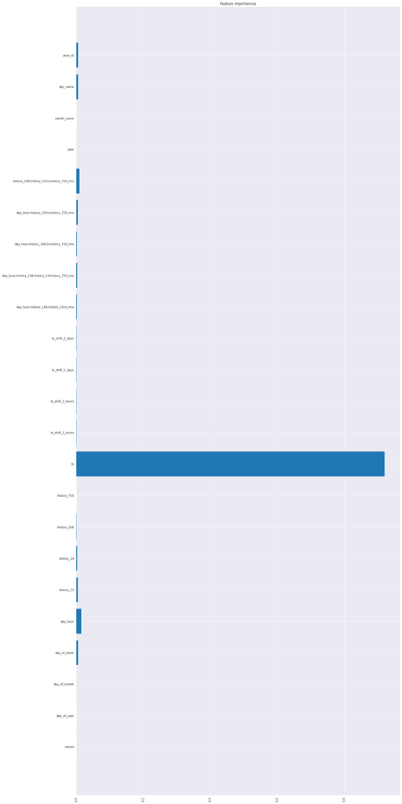

```python
%%time
dataset = datasets[0].copy()
regressor = xgb.XGBRegressor(random_state=42,max_depth=7, learning_rate=0.2,n_estimators=50,objective='reg:squarederror')
cols = ['day_hour','history_168','history_24','ts','history_720']
error0 = error_estimation(dataset, params_prep = [0,0,2,2,4,23],
                 fill_empty = False,ts_mean_values=None,
                 cat_encoder = TargetEncoder(),
                 cols_to_drop=['srmx_forecast'],
                 cols_to_mix_feats = cols ,
                 cols_for_q=[],cols_for_c = [],
                 train_lims = ['2015-12-23 00:00:00','2016-05-01 00:00:00'],
                 reg_algo = regressor,
                 verbose=True,
                 show_fe_importances=True
                 )
gc.collect()
```

```
------------------
Solving with params[3, 0, 2, 2, 2, 30]
------------------
------------------
creation harmonic_fe, autoreg_fe completed
------------------
------------------
creation deriv_feats completed
------------------
------------------
prep datasets completed
------------------
------------------
preproc completed
------------------
------------------
fitting the model...
------------------
model fitted
------------------
------------------
predicting and scoring...
------------------
params[k1,k2,k3,k4,k5,k6]: [3, 0, 2, 2, 2, 30],mean absolute error: 15.861107608232347
------------------
------------------
CPU times: user 4min 31s, sys: 489 ms, total: 4min 32s
Wall time: 4min 33s
```

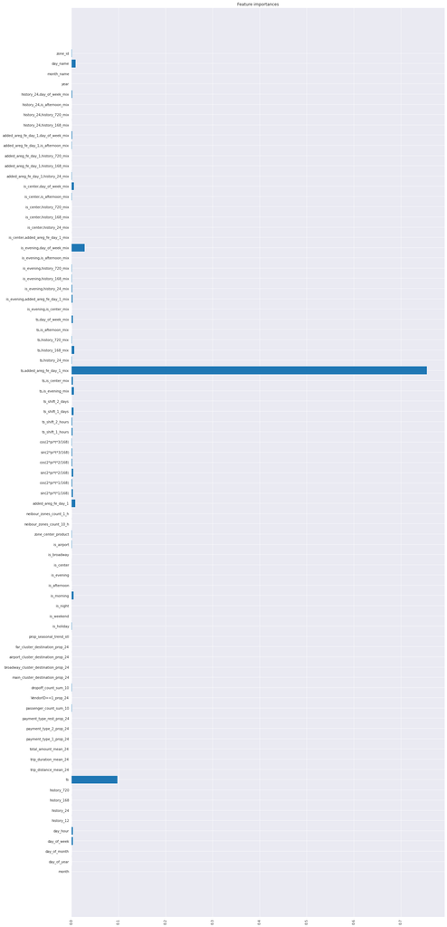

```python
%%time
dataset = datasets_new[0].copy()
regressor = xgb.XGBRegressor(random_state=42,max_depth=7, learning_rate=0.2,n_estimators=150,objective='reg:squarederror')
cols = ['ts','is_evening','is_center','added_areg_fe_day_1',
        'history_24','history_168','history_720','is_afternoon','day_of_week']
error0 = error_estimation(dataset, params_prep = [3,0,2,2,2,30],
                 fill_empty = False,ts_mean_values=None,
                 cat_encoder = TargetEncoder(),
                 cols_to_drop=['1_hours_forecast','srmx_forecast','added_areg_fe_week_1'],
                 cols_to_mix_feats = cols ,
                 cols_for_q=[],cols_for_c = [],
                 train_lims = ['2016-02-01 00:00:00','2016-05-01 00:00:00'],
                 reg_algo = regressor,
                 verbose=True,
                 show_fe_importances=True
                 )
gc.collect()
```

```
------------------
Solving with params[2, 0, 4, 2, 2, 23]
------------------
------------------
creation harmonic_fe, autoreg_fe completed
------------------
------------------
creation deriv_feats completed
------------------
------------------
prep datasets completed
------------------
------------------
preproc completed
------------------
------------------
fitting the model...
------------------
model fitted
------------------
------------------
predicting and scoring...
------------------
params[k1,k2,k3,k4,k5,k6]: [2, 0, 4, 2, 2, 23],mean absolute error: 30.16137228970442
------------------
------------------
CPU times: user 1min 3s, sys: 940 ms, total: 1min 4s
Wall time: 1min 4s
```

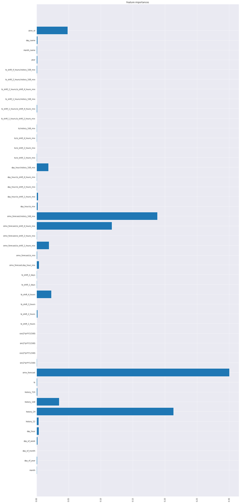

```python
%%time
dataset = datasets[5].copy()
regressor = xgb.XGBRegressor(random_state=42,max_depth=7,colsample_bytree= 0.5, learning_rate = 0.2,
                             min_child_weight= 3,n_estimators=50,objective='reg:squarederror')
cols = ['srmx_forecast','day_hour','ts','ts_shift_1_hours','ts_shift_2_hours','ts_shift_4_hours','history_168']
error1 = error_estimation(dataset, params_prep = [2,0,4,2,2,23],
                 fill_empty = False,ts_mean_values=None,
                 cat_encoder = TargetEncoder(),
                 cols_to_drop=[],
                 cols_to_mix_feats = cols ,
                 cols_for_q=[],cols_for_c = [],
                 train_lims = ['2015-12-23 00:00:00','2016-05-01 00:00:00'],
                 reg_algo = regressor,
                 verbose=True,
                 show_fe_importances=True
                 )
gc.collect()
```

```
------------------
Solving with params[3, 0, 4, 2, 2, 30]
------------------
------------------
creation harmonic_fe, autoreg_fe completed
------------------
------------------
creation deriv_feats completed
------------------
------------------
prep datasets completed
------------------
------------------
preproc completed
------------------
------------------
fitting the model...
------------------
model fitted
------------------
------------------
predicting and scoring...
------------------
params[k1,k2,k3,k4,k5,k6]: [3, 0, 4, 2, 2, 30],mean absolute error: 21.085398795896477
------------------
------------------
CPU times: user 5min 18s, sys: 626 ms, total: 5min 19s
Wall time: 5min 21s
```

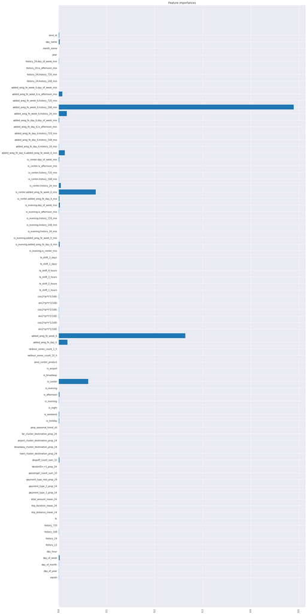

```python
%%time
dataset = datasets_new[5].copy()
regressor = xgb.XGBRegressor(random_state=42,max_depth=7,colsample_bytree= 0.5, learning_rate = 0.2,
                             min_child_weight= 3,n_estimators=300,objective='reg:squarederror')
cols = ['is_evening','is_center','added_areg_fe_day_6','added_areg_fe_week_6',
        'history_24','history_168','history_720','is_afternoon','day_of_week']
error1 = error_estimation(dataset, params_prep = [3,0,4,2,2,30],
                 fill_empty = False,ts_mean_values=None,
                 cat_encoder = TargetEncoder(),
                 cols_to_drop=['srmx_forecast','6_hours_forecast'],
                 cols_to_mix_feats = cols ,
                 cols_for_q=[],cols_for_c = [],
                 train_lims = ['2016-02-01 00:00:00','2016-05-01 00:00:00'],
                 reg_algo = regressor,
                 verbose=True,
                 show_fe_importances=True
                 )
gc.collect()
```

```
------------------
Solving with params[3, 0, 4, 2, 2, 30]
------------------
------------------
creation harmonic_fe, autoreg_fe completed
------------------
------------------
creation deriv_feats completed
------------------
------------------
prep datasets completed
------------------
------------------
preproc completed
------------------
------------------
fitting the model...
------------------
model fitted
------------------
------------------
predicting and scoring...
------------------
params[k1,k2,k3,k4,k5,k6]: [3, 0, 4, 2, 2, 30],mean absolute error: 19.931974973363065
------------------
------------------
CPU times: user 1min 2s, sys: 436 ms, total: 1min 3s
Wall time: 1min 3s
```

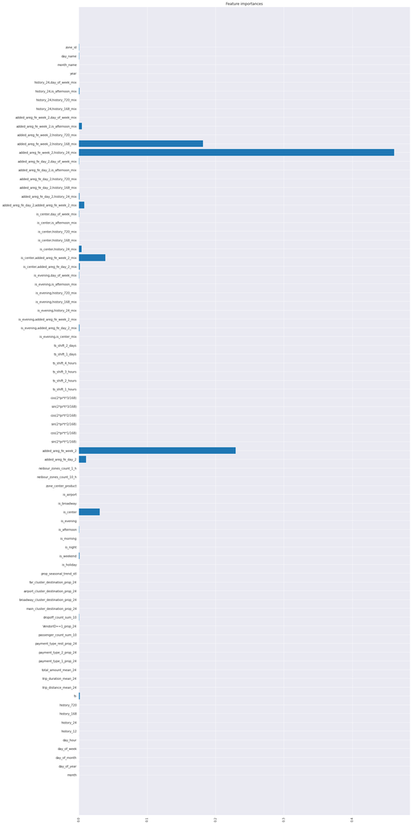

```python
%%time
dataset = datasets_new[1].copy()
regressor = xgb.XGBRegressor(random_state=42,max_depth=7,colsample_bytree= 0.5, learning_rate = 0.2,
                             min_child_weight= 3,n_estimators=50,objective='reg:squarederror')
cols = ['is_evening','is_center','added_areg_fe_day_2','added_areg_fe_week_2',
        'history_24','history_168','history_720','is_afternoon','day_of_week']
error1 = error_estimation(dataset, params_prep = [3,0,4,2,2,30],
                 fill_empty = False,ts_mean_values=None,
                 cat_encoder = TargetEncoder(),
                 cols_to_drop=['srmx_forecast','2_hours_forecast'],
                 cols_to_mix_feats = cols ,
                 cols_for_q=[],cols_for_c = [],
                 train_lims = ['2016-02-01 00:00:00','2016-05-01 00:00:00'],
                 reg_algo = regressor,
                 verbose=True,
                 show_fe_importances=True
                 )
gc.collect()
```

```
------------------
Solving with params[3, 0, 2, 2, 2, 30]
------------------
------------------
creation harmonic_fe, autoreg_fe completed
------------------
------------------
creation deriv_feats completed
------------------
------------------
prep datasets completed
------------------
------------------
preproc completed
------------------
------------------
fitting the model...
------------------
model fitted
------------------
------------------
predicting and scoring...
------------------
params[k1,k2,k3,k4,k5,k6]: [3, 0, 2, 2, 2, 30],mean absolute error: 19.19538530449817
------------------
------------------
CPU times: user 1min 40s, sys: 424 ms, total: 1min 40s
Wall time: 1min 41s
```

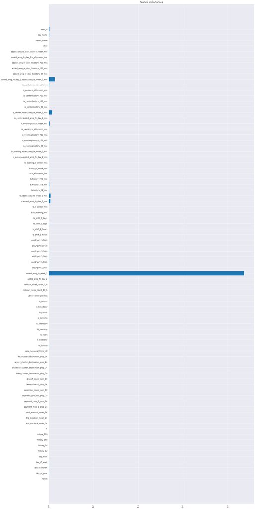

```python
%%time
#200 деревьев в итоге
dataset = datasets_new[1].copy()
regressor = xgb.XGBRegressor(random_state=42,max_depth=7, learning_rate=0.2,n_estimators=50,objective='reg:squarederror')
cols = ['ts','is_evening','is_center','added_areg_fe_day_2','added_areg_fe_week_2',
        'history_24','history_168','history_720','is_afternoon','day_of_week']
error0 = error_estimation(dataset, params_prep = [3,0,2,2,2,30],
                 fill_empty = False,ts_mean_values=None,
                 cat_encoder = TargetEncoder(),
                 cols_to_drop=['2_hours_forecast','srmx_forecast'],
                 cols_to_mix_feats = cols ,
                 cols_for_q=[],cols_for_c = [],
                 train_lims = ['2016-02-01 00:00:00','2016-05-01 00:00:00'],
                 reg_algo = regressor,
                 verbose=True,
                 show_fe_importances=True
                 )
gc.collect()
```

```
------------------
Solving with params[3, 0, 4, 2, 2, 30]
------------------
------------------
creation harmonic_fe, autoreg_fe completed
------------------
------------------
creation deriv_feats completed
------------------
------------------
prep datasets completed
------------------
------------------
preproc completed
------------------
------------------
fitting the model...
------------------
model fitted
------------------
------------------
predicting and scoring...
------------------
params[k1,k2,k3,k4,k5,k6]: [3, 0, 4, 2, 2, 30],mean absolute error: 21.117674844406253
------------------
------------------
CPU times: user 1min 5s, sys: 426 ms, total: 1min 5s
Wall time: 1min 5s
```

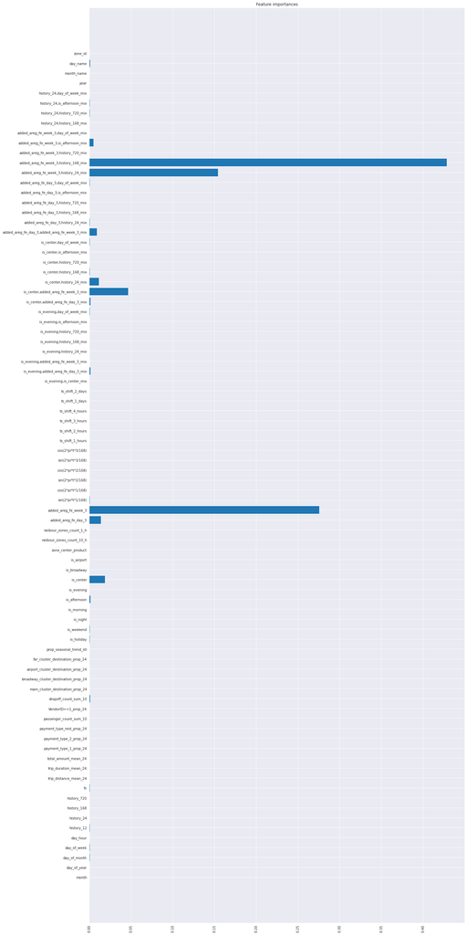

```python
%%time
dataset = datasets_new[2].copy()
regressor = xgb.XGBRegressor(random_state=42,max_depth=7,colsample_bytree= 0.5, learning_rate = 0.2,
                             min_child_weight= 3,n_estimators=50,objective='reg:squarederror')
cols = ['is_evening','is_center','added_areg_fe_day_3','added_areg_fe_week_3',
        'history_24','history_168','history_720','is_afternoon','day_of_week']
error1 = error_estimation(dataset, params_prep = [3,0,4,2,2,30],
                 fill_empty = False,ts_mean_values=None,
                 cat_encoder = TargetEncoder(),
                 cols_to_drop=['srmx_forecast','3_hours_forecast'],
                 cols_to_mix_feats = cols ,
                 cols_for_q=[],cols_for_c = [],
                 train_lims = ['2016-02-01 00:00:00','2016-05-01 00:00:00'],
                 reg_algo = regressor,
                 verbose=True,
                 show_fe_importances=True
                 )
gc.collect()
```

```
------------------
Solving with params[3, 0, 2, 2, 2, 30]
------------------
------------------
creation harmonic_fe, autoreg_fe completed
------------------
------------------
creation deriv_feats completed
------------------
------------------
prep datasets completed
------------------
------------------
preproc completed
------------------
------------------
fitting the model...
------------------
model fitted
------------------
------------------
predicting and scoring...
------------------
params[k1,k2,k3,k4,k5,k6]: [3, 0, 2, 2, 2, 30],mean absolute error: 20.583264087277538
------------------
------------------
CPU times: user 1min 40s, sys: 444 ms, total: 1min 40s
Wall time: 1min 41s
```

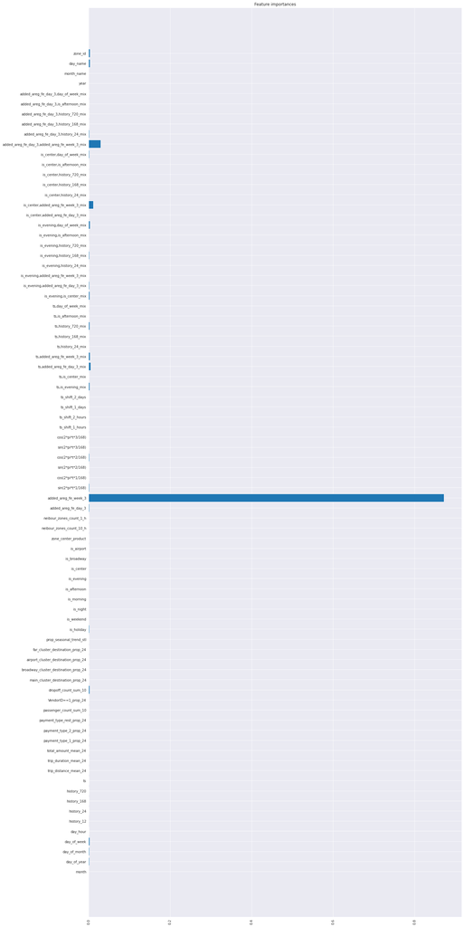

```python
%%time
#200 деревьев в итоге
dataset = datasets_new[2].copy()
regressor = xgb.XGBRegressor(random_state=42,max_depth=7, learning_rate=0.2,n_estimators=50,objective='reg:squarederror')
cols = ['ts','is_evening','is_center','added_areg_fe_day_3','added_areg_fe_week_3',
        'history_24','history_168','history_720','is_afternoon','day_of_week']
error0 = error_estimation(dataset, params_prep = [3,0,2,2,2,30],
                 fill_empty = False,ts_mean_values=None,
                 cat_encoder = TargetEncoder(),
                 cols_to_drop=['3_hours_forecast','srmx_forecast'],
                 cols_to_mix_feats = cols ,
                 cols_for_q=[],cols_for_c = [],
                 train_lims = ['2016-02-01 00:00:00','2016-05-01 00:00:00'],
                 reg_algo = regressor,
                 verbose=True,
                 show_fe_importances=True
                 )
gc.collect()
```

```
------------------
Solving with params[3, 0, 4, 2, 2, 30]
------------------
------------------
creation harmonic_fe, autoreg_fe completed
------------------
------------------
creation deriv_feats completed
------------------
------------------
prep datasets completed
------------------
------------------
preproc completed
------------------
------------------
fitting the model...
------------------
model fitted
------------------
------------------
predicting and scoring...
------------------
params[k1,k2,k3,k4,k5,k6]: [3, 0, 4, 2, 2, 30],mean absolute error: 23.294756174955815
------------------
------------------
CPU times: user 1min 3s, sys: 438 ms, total: 1min 3s
Wall time: 1min 3s
```

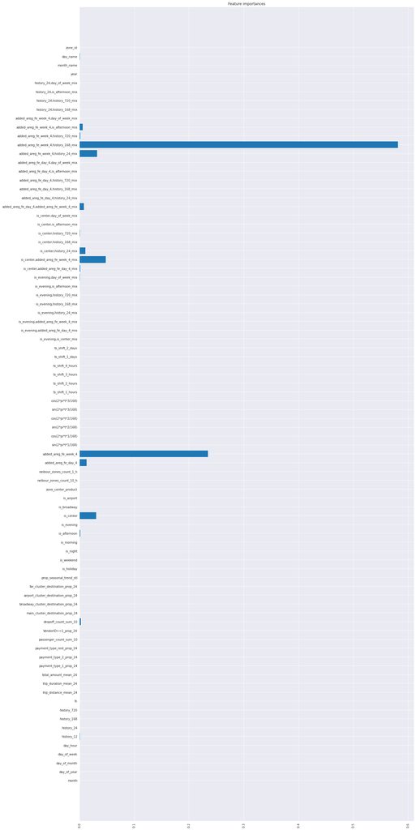

```python
%%time
dataset = datasets_new[3].copy()
regressor = xgb.XGBRegressor(random_state=42,max_depth=7,colsample_bytree= 0.5, learning_rate = 0.2,
                             min_child_weight= 3,n_estimators=50,objective='reg:squarederror')
cols = ['is_evening','is_center','added_areg_fe_day_4','added_areg_fe_week_4',
        'history_24','history_168','history_720','is_afternoon','day_of_week']
error1 = error_estimation(dataset, params_prep = [3,0,4,2,2,30],
                 fill_empty = False,ts_mean_values=None,
                 cat_encoder = TargetEncoder(),
                 cols_to_drop=['srmx_forecast','4_hours_forecast'],
                 cols_to_mix_feats = cols ,
                 cols_for_q=[],cols_for_c = [],
                 train_lims = ['2016-02-01 00:00:00','2016-05-01 00:00:00'],
                 reg_algo = regressor,
                 verbose=True,
                 show_fe_importances=True
                 )
gc.collect()
```

```
------------------
Solving with params[3, 0, 2, 2, 2, 30]
------------------
------------------
creation harmonic_fe, autoreg_fe completed
------------------
------------------
creation deriv_feats completed
------------------
------------------
prep datasets completed
------------------
------------------
preproc completed
------------------
------------------
fitting the model...
------------------
model fitted
------------------
------------------
predicting and scoring...
------------------
params[k1,k2,k3,k4,k5,k6]: [3, 0, 2, 2, 2, 30],mean absolute error: 20.656522616431047
------------------
------------------
CPU times: user 1min 40s, sys: 868 ms, total: 1min 41s
Wall time: 1min 41s
```

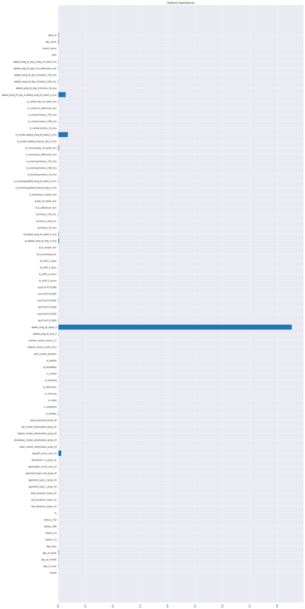

```python
%%time
#200 деревьев в итоге
dataset = datasets_new[3].copy()
regressor = xgb.XGBRegressor(random_state=42,max_depth=7, learning_rate=0.2,n_estimators=50,objective='reg:squarederror')
cols = ['ts','is_evening','is_center','added_areg_fe_day_4','added_areg_fe_week_4',
        'history_24','history_168','history_720','is_afternoon','day_of_week']
error0 = error_estimation(dataset, params_prep = [3,0,2,2,2,30],
                 fill_empty = False,ts_mean_values=None,
                 cat_encoder = TargetEncoder(),
                 cols_to_drop=['4_hours_forecast','srmx_forecast'],
                 cols_to_mix_feats = cols ,
                 cols_for_q=[],cols_for_c = [],
                 train_lims = ['2016-02-01 00:00:00','2016-05-01 00:00:00'],
                 reg_algo = regressor,
                 verbose=True,
                 show_fe_importances=True
                 )
gc.collect()
```

```
------------------
Solving with params[3, 0, 4, 2, 2, 30]
------------------
------------------
creation harmonic_fe, autoreg_fe completed
------------------
------------------
creation deriv_feats completed
------------------
------------------
prep datasets completed
------------------
------------------
preproc completed
------------------
------------------
fitting the model...
------------------
model fitted
------------------
------------------
predicting and scoring...
------------------
params[k1,k2,k3,k4,k5,k6]: [3, 0, 4, 2, 2, 30],mean absolute error: 21.446112142792142
------------------
------------------
CPU times: user 1min 3s, sys: 441 ms, total: 1min 3s
Wall time: 1min 3s
```

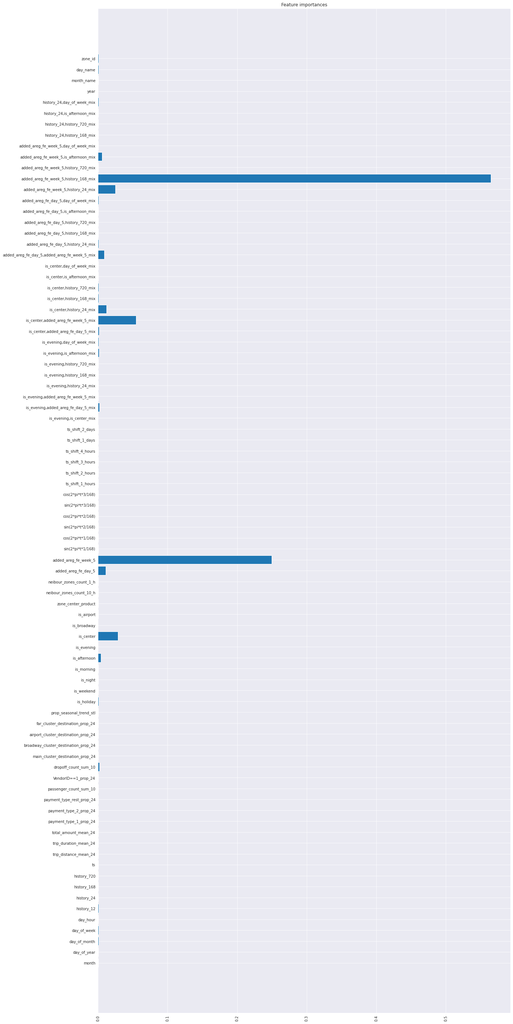

```python
%%time
dataset = datasets_new[4].copy()
regressor = xgb.XGBRegressor(random_state=42,max_depth=7,colsample_bytree= 0.5, learning_rate = 0.2,
                             min_child_weight= 3,n_estimators=50,objective='reg:squarederror')
cols = ['is_evening','is_center','added_areg_fe_day_5','added_areg_fe_week_5',
        'history_24','history_168','history_720','is_afternoon','day_of_week']
error1 = error_estimation(dataset, params_prep = [3,0,4,2,2,30],
                 fill_empty = False,ts_mean_values=None,
                 cat_encoder = TargetEncoder(),
                 cols_to_drop=['srmx_forecast','5_hours_forecast'],
                 cols_to_mix_feats = cols ,
                 cols_for_q=[],cols_for_c = [],
                 train_lims = ['2016-02-01 00:00:00','2016-05-01 00:00:00'],
                 reg_algo = regressor,
                 verbose=True,
                 show_fe_importances=True
                 )
gc.collect()
```

```
------------------
Solving with params[3, 0, 2, 2, 2, 30]
------------------
------------------
creation harmonic_fe, autoreg_fe completed
------------------
------------------
creation deriv_feats completed
------------------
------------------
prep datasets completed
------------------
------------------
preproc completed
------------------
------------------
fitting the model...
------------------
model fitted
------------------
------------------
predicting and scoring...
------------------
params[k1,k2,k3,k4,k5,k6]: [3, 0, 2, 2, 2, 30],mean absolute error: 21.16654911611348
------------------
------------------
CPU times: user 1min 42s, sys: 871 ms, total: 1min 43s
Wall time: 1min 44s
```

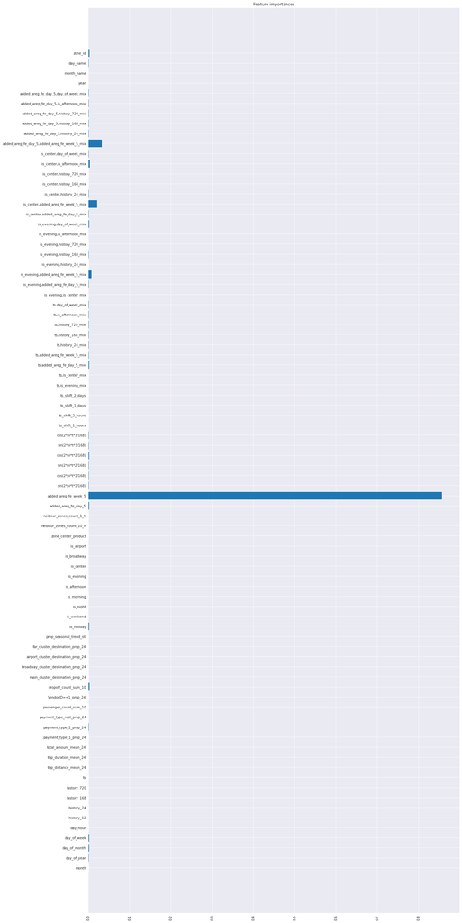

```python
%%time
#200 деревьев в итоге
dataset = datasets_new[4].copy()
regressor = xgb.XGBRegressor(random_state=42,max_depth=7, learning_rate=0.2,n_estimators=50,objective='reg:squarederror')
cols = ['ts','is_evening','is_center','added_areg_fe_day_5','added_areg_fe_week_5',
        'history_24','history_168','history_720','is_afternoon','day_of_week']
error0 = error_estimation(dataset, params_prep = [3,0,2,2,2,30],
                 fill_empty = False,ts_mean_values=None,
                 cat_encoder = TargetEncoder(),
                 cols_to_drop=['5_hours_forecast','srmx_forecast'],
                 cols_to_mix_feats = cols ,
                 cols_for_q=[],cols_for_c = [],
                 train_lims = ['2016-02-01 00:00:00','2016-05-01 00:00:00'],
                 reg_algo = regressor,
                 verbose=True,
                 show_fe_importances=True
                 )
gc.collect()
```

Итак, применим полученные эмпирическим путем модели для оценки ошибки на данных за май, а затем для участия в соревновании. При этом, обучать на мае не будем, т.к. много аномалий.

```python
%%time
dataset = datasets_new[0].copy()
regressor = xgb.XGBRegressor(random_state=42,max_depth=7, learning_rate=0.2,n_estimators=150,objective='reg:squarederror')
cols_to_mix = ['ts','is_evening','is_center','added_areg_fe_day_1',
              'history_24','history_168','history_720','is_afternoon','day_of_week']
cols_to_drop = ['1_hours_forecast','srmx_forecast','added_areg_fe_week_1']

params_prep = [3,0,2,2,2,30]

model_1_may = create_model(dataset, params_prep = params_prep,
                 fill_empty = False,ts_mean_values=None,
                 cat_encoder = TargetEncoder(),
                 cols_to_drop=cols_to_drop,
                 cols_to_mix_feats = cols_to_mix,
                 cols_for_q=[],cols_for_c = [],
                 train_lims = ['2016-02-01 00:00:00','2016-04-30 23:00:00'],
                 reg_algo = regressor,
                 verbose=True,
                 show_fe_importances=False
                 )
gc.collect()


data_may1 = prepare_data_to_predict(dataset, params_prep = params_prep,
                 fill_empty = False,ts_mean_values=None,
                 cols_to_drop=cols_to_drop,
                 cols_to_mix_feats = cols_to_mix,
                 cols_for_q=[],cols_for_c = [],
                 test_lims = ['2016-04-30 23:00:00','2016-05-31 18:00:00'],
                 verbose=True,
                 )

gc.collect()

data_june1 = prepare_data_to_predict(dataset, params_prep = params_prep,
                 fill_empty = False,ts_mean_values=None,
                 cols_to_drop=cols_to_drop,
                 cols_to_mix_feats = cols_to_mix,
                 cols_for_q=[],cols_for_c = [],
                 test_lims = ['2016-05-31 23:00:00','2016-06-30 18:00:00'],
                 verbose=True,
                 )

gc.collect()
```

[output not shown]

[output cut: 19 more lines]

```
------------------
------------------
Solving with params[3, 0, 2, 2, 2, 30]
------------------
------------------
creation harmonic_fe, autoreg_fe completed
------------------
------------------
creation deriv_feats completed
------------------
------------------
prep dataset completed
------------------
CPU times: user 4min 53s, sys: 992 ms, total: 4min 54s
Wall time: 4min 56s
```

```python
%%time
dataset = datasets_new[1].copy()
regressor = xgb.XGBRegressor(random_state=42,max_depth=7, learning_rate=0.2,n_estimators=200,objective='reg:squarederror')
cols_to_mix = ['ts','is_evening','is_center','added_areg_fe_day_2','added_areg_fe_week_2',
              'history_24','history_168','history_720','is_afternoon','day_of_week']
cols_to_drop = ['2_hours_forecast','srmx_forecast']

params_prep = [3,0,2,2,2,30]

model_2_may = create_model(dataset, params_prep = params_prep,
                 fill_empty = False,ts_mean_values=None,
                 cat_encoder = TargetEncoder(),
                 cols_to_drop=cols_to_drop,
                 cols_to_mix_feats = cols_to_mix,
                 cols_for_q=[],cols_for_c = [],
                 train_lims = ['2016-02-01 00:00:00','2016-04-30 23:00:00'],
                 reg_algo = regressor,
                 verbose=True,
                 show_fe_importances=False
                 )
gc.collect()


data_may2 = prepare_data_to_predict(dataset, params_prep = params_prep,
                 fill_empty = False,ts_mean_values=None,
                 cols_to_drop=cols_to_drop,
                 cols_to_mix_feats = cols_to_mix,
                 cols_for_q=[],cols_for_c = [],
                 test_lims = ['2016-04-30 23:00:00','2016-05-31 18:00:00'],
                 verbose=True,
                 )

gc.collect()

data_june2 = prepare_data_to_predict(dataset, params_prep = params_prep,
                 fill_empty = False,ts_mean_values=None,
                 cols_to_drop=cols_to_drop,
                 cols_to_mix_feats = cols_to_mix,
                 cols_for_q=[],cols_for_c = [],
                 test_lims = ['2016-05-31 23:00:00','2016-06-30 18:00:00'],
                 verbose=True,
                 )

gc.collect()
```

[output not shown]

[output cut: 19 more lines]

```
------------------
------------------
Solving with params[3, 0, 2, 2, 2, 30]
------------------
------------------
creation harmonic_fe, autoreg_fe completed
------------------
------------------
creation deriv_feats completed
------------------
------------------
prep dataset completed
------------------
CPU times: user 6min 26s, sys: 634 ms, total: 6min 27s
Wall time: 6min 33s
```

```python
%%time
dataset = datasets_new[2].copy()
regressor = xgb.XGBRegressor(random_state=42,max_depth=7, learning_rate=0.2,n_estimators=200,objective='reg:squarederror')
cols_to_mix = ['ts','is_evening','is_center','added_areg_fe_day_3','added_areg_fe_week_3',
              'history_24','history_168','history_720','is_afternoon','day_of_week']
cols_to_drop = ['3_hours_forecast','srmx_forecast']

params_prep = [3,0,2,2,2,30]

model_3_may = create_model(dataset, params_prep = params_prep,
                 fill_empty = False,ts_mean_values=None,
                 cat_encoder = TargetEncoder(),
                 cols_to_drop=cols_to_drop,
                 cols_to_mix_feats = cols_to_mix,
                 cols_for_q=[],cols_for_c = [],
                 train_lims = ['2016-02-01 00:00:00','2016-04-30 23:00:00'],
                 reg_algo = regressor,
                 verbose=True,
                 show_fe_importances=False
                 )
gc.collect()


data_may3 = prepare_data_to_predict(dataset, params_prep = params_prep,
                 fill_empty = False,ts_mean_values=None,
                 cols_to_drop=cols_to_drop,
                 cols_to_mix_feats = cols_to_mix,
                 cols_for_q=[],cols_for_c = [],
                 test_lims = ['2016-04-30 23:00:00','2016-05-31 18:00:00'],
                 verbose=True,
                 )

gc.collect()

data_june3 = prepare_data_to_predict(dataset, params_prep = params_prep,
                 fill_empty = False,ts_mean_values=None,
                 cols_to_drop=cols_to_drop,
                 cols_to_mix_feats = cols_to_mix,
                 cols_for_q=[],cols_for_c = [],
                 test_lims = ['2016-05-31 23:00:00','2016-06-30 18:00:00'],
                 verbose=True,
                 )

gc.collect()
```

[output not shown]

[output cut: 19 more lines]

```
------------------
------------------
Solving with params[3, 0, 2, 2, 2, 30]
------------------
------------------
creation harmonic_fe, autoreg_fe completed
------------------
------------------
creation deriv_feats completed
------------------
------------------
prep dataset completed
------------------
CPU times: user 6min 31s, sys: 832 ms, total: 6min 32s
Wall time: 6min 38s
```

```python
%%time
dataset = datasets_new[3].copy()
regressor = xgb.XGBRegressor(random_state=42,max_depth=7, learning_rate=0.2,n_estimators=200,objective='reg:squarederror')
cols_to_mix = ['ts','is_evening','is_center','added_areg_fe_day_4','added_areg_fe_week_4',
              'history_24','history_168','history_720','is_afternoon','day_of_week']
cols_to_drop = ['4_hours_forecast','srmx_forecast']

params_prep = [3,0,2,2,2,30]

model_4_may = create_model(dataset, params_prep = params_prep,
                 fill_empty = False,ts_mean_values=None,
                 cat_encoder = TargetEncoder(),
                 cols_to_drop=cols_to_drop,
                 cols_to_mix_feats = cols_to_mix,
                 cols_for_q=[],cols_for_c = [],
                 train_lims = ['2016-02-01 00:00:00','2016-04-30 23:00:00'],
                 reg_algo = regressor,
                 verbose=True,
                 show_fe_importances=False
                 )
gc.collect()


data_may4 = prepare_data_to_predict(dataset, params_prep = params_prep,
                 fill_empty = False,ts_mean_values=None,
                 cols_to_drop=cols_to_drop,
                 cols_to_mix_feats = cols_to_mix,
                 cols_for_q=[],cols_for_c = [],
                 test_lims = ['2016-04-30 23:00:00','2016-05-31 18:00:00'],
                 verbose=True,
                 )

gc.collect()

data_june4 = prepare_data_to_predict(dataset, params_prep = params_prep,
                 fill_empty = False,ts_mean_values=None,
                 cols_to_drop=cols_to_drop,
                 cols_to_mix_feats = cols_to_mix,
                 cols_for_q=[],cols_for_c = [],
                 test_lims = ['2016-05-31 23:00:00','2016-06-30 18:00:00'],
                 verbose=True,
                 )

gc.collect()
```

[output not shown]

[output cut: 19 more lines]

```
------------------
------------------
Solving with params[3, 0, 2, 2, 2, 30]
------------------
------------------
creation harmonic_fe, autoreg_fe completed
------------------
------------------
creation deriv_feats completed
------------------
------------------
prep dataset completed
------------------
CPU times: user 6min 15s, sys: 1.55 s, total: 6min 17s
Wall time: 6min 19s
```

```python
%%time
dataset = datasets_new[4].copy()
regressor = xgb.XGBRegressor(random_state=42,max_depth=7, learning_rate=0.2,n_estimators=200,objective='reg:squarederror')
cols_to_mix = ['ts','is_evening','is_center','added_areg_fe_day_5','added_areg_fe_week_5',
              'history_24','history_168','history_720','is_afternoon','day_of_week']
cols_to_drop = ['5_hours_forecast','srmx_forecast']

params_prep = [3,0,2,2,2,30]

model_5_may = create_model(dataset, params_prep = params_prep,
                 fill_empty = False,ts_mean_values=None,
                 cat_encoder = TargetEncoder(),
                 cols_to_drop=cols_to_drop,
                 cols_to_mix_feats = cols_to_mix,
                 cols_for_q=[],cols_for_c = [],
                 train_lims = ['2016-02-01 00:00:00','2016-04-30 23:00:00'],
                 reg_algo = regressor,
                 verbose=True,
                 show_fe_importances=False
                 )
gc.collect()


data_may5 = prepare_data_to_predict(dataset, params_prep = params_prep,
                 fill_empty = False,ts_mean_values=None,
                 cols_to_drop=cols_to_drop,
                 cols_to_mix_feats = cols_to_mix,
                 cols_for_q=[],cols_for_c = [],
                 test_lims = ['2016-04-30 23:00:00','2016-05-31 18:00:00'],
                 verbose=True,
                 )

gc.collect()

data_june5 = prepare_data_to_predict(dataset, params_prep = params_prep,
                 fill_empty = False,ts_mean_values=None,
                 cols_to_drop=cols_to_drop,
                 cols_to_mix_feats = cols_to_mix,
                 cols_for_q=[],cols_for_c = [],
                 test_lims = ['2016-05-31 23:00:00','2016-06-30 18:00:00'],
                 verbose=True,
                 )

gc.collect()
```

[output not shown]

[output cut: 19 more lines]

```
------------------
------------------
Solving with params[3, 0, 2, 2, 2, 30]
------------------
------------------
creation harmonic_fe, autoreg_fe completed
------------------
------------------
creation deriv_feats completed
------------------
------------------
prep dataset completed
------------------
CPU times: user 6min 25s, sys: 835 ms, total: 6min 25s
Wall time: 6min 28s
```

```python
%%time
dataset = datasets_new[5].copy()
regressor = xgb.XGBRegressor(random_state=42,max_depth=7,colsample_bytree= 0.5, learning_rate = 0.2,
                             min_child_weight= 3,n_estimators=300,objective='reg:squarederror')
cols_to_mix = ['is_evening','is_center','added_areg_fe_day_6','added_areg_fe_week_6',
        'history_24','history_168','history_720','is_afternoon','day_of_week']
cols_to_drop = ['srmx_forecast','6_hours_forecast']

params_prep = [3,0,4,2,2,30]

model_6_may = create_model(dataset, params_prep = params_prep,
                 fill_empty = False,ts_mean_values=None,
                 cat_encoder = TargetEncoder(),
                 cols_to_drop=cols_to_drop,
                 cols_to_mix_feats = cols_to_mix,
                 cols_for_q=[],cols_for_c = [],
                 train_lims = ['2016-02-01 00:00:00','2016-04-30 23:00:00'],
                 reg_algo = regressor,
                 verbose=True,
                 show_fe_importances=False
                 )
gc.collect()


data_may6 = prepare_data_to_predict(dataset, params_prep = params_prep,
                 fill_empty = False,ts_mean_values=None,
                 cols_to_drop=cols_to_drop,
                 cols_to_mix_feats = cols_to_mix,
                 cols_for_q=[],cols_for_c = [],
                 test_lims = ['2016-04-30 23:00:00','2016-05-31 18:00:00'],
                 verbose=True,
                 )

gc.collect()

data_june6 = prepare_data_to_predict(dataset, params_prep = params_prep,
                 fill_empty = False,ts_mean_values=None,
                 cols_to_drop=cols_to_drop,
                 cols_to_mix_feats = cols_to_mix,
                 cols_for_q=[],cols_for_c = [],
                 test_lims = ['2016-05-31 23:00:00','2016-06-30 18:00:00'],
                 verbose=True,
                 )

gc.collect()
```

[output not shown]

[output cut: 19 more lines]

```
------------------
------------------
Solving with params[3, 0, 4, 2, 2, 30]
------------------
------------------
creation harmonic_fe, autoreg_fe completed
------------------
------------------
creation deriv_feats completed
------------------
------------------
prep dataset completed
------------------
CPU times: user 5min 36s, sys: 2.07 s, total: 5min 38s
Wall time: 5min 41s
```

```python
models_may = [model_1_may,model_2_may,model_3_may,model_4_may,model_5_may,model_6_may]
data_may = [data_may1,data_may2,data_may3,data_may4,data_may5,data_may6]
data_june = [data_june1,data_june2,data_june3,data_june4,data_june5,data_june6]
```

```python
%%time
prediction_may = pd.DataFrame()
for (ind,(data,model)) in enumerate(zip(data_may,models_may)):
  prediction  = model.predict(data.drop(columns=['target']).values)
  prediction_may[f'{ind+1}_hours_forecast'] = prediction

prediction_may.to_csv(os.path.join(PATH_TO_DATA,'regression_new_fe_pred_may.csv'))
```

```
CPU times: user 14.3 s, sys: 400 ms, total: 14.7 s
Wall time: 14.8 s
```

```python
%%time
prediction_june = pd.DataFrame()
for (ind,(data,model)) in enumerate(zip(data_june,models_may)):
  prediction  = model.predict(data.drop(columns=['target']).values)
  prediction_june[f'{ind+1}_hours_forecast'] = prediction

prediction_june.to_csv(os.path.join(PATH_TO_DATA,'regression_new_fe_pred_june.csv'))
```

```
CPU times: user 13.8 s, sys: 369 ms, total: 14.2 s
Wall time: 14.3 s
```

```python
%%time
time_series_6_month = pd.read_csv(os.path.join(PATH_TO_DATA,'time_series_6_month.csv'),index_col=0)
time_series_6_month.columns = range(1,2501)
time_series_6_month.index = pd.to_datetime(time_series_6_month.index)
time_series_6_month.head()
```

```
CPU times: user 1.35 s, sys: 47.5 ms, total: 1.39 s
Wall time: 1.76 s
```

```python
zones = list(datasets[0].zone_id.unique())
time_points_may =  list(pd.date_range(start=pd.to_datetime('2016-04-30 23:00:00'),end=pd.to_datetime('2016-05-31 17:00:00'),freq='1H'))
```

```python
real_may = create_result(time_series_6_month[zones],time_points_may)
real_may.head()
```

|  | y |
| --- | --- |
| 1075_2016-04-30_23_1 | 71 |
| 1075_2016-04-30_23_2 | 37 |
| 1075_2016-04-30_23_3 | 10 |
| 1075_2016-04-30_23_4 | 14 |
| 1075_2016-04-30_23_5 | 6 |

```python
pred_may_df = pd.read_csv(os.path.join(PATH_TO_DATA,'regression_new_fe_pred_may.csv'),index_col=0)
pred_may_df['zone_id'] = data_may1.zone_id.values
pred_may_df['datetime'] = data_may1.datetime.values
result_may = create_submission(pred_may_df)
result_may.head()
```

|  | y |
| --- | --- |
| 1075_2016-04-30_23_1 | 73.8392 |
| 1075_2016-04-30_23_2 | 48.5749 |
| 1075_2016-04-30_23_3 | 28.5692 |
| 1075_2016-04-30_23_4 | 19.2215 |
| 1075_2016-04-30_23_5 | 20.4025 |

```python
error_pred = mae(real_may,result_may)
error_pred
```

```
20.298857882902553
```

Учитывая, что на прошлой неделе ошибка на данных за май была более 25, виден прогресс. Проверим модели в соревновании.

```python
pred_june_df = pd.read_csv(os.path.join(PATH_TO_DATA,'regression_new_fe_pred_june.csv'),index_col=0)
pred_june_df['zone_id'] = data_june1.zone_id.values
pred_june_df['datetime'] = data_june1.datetime.values
pred_june_df.head()
result_june = create_submission(pred_june_df)

result_june.head()
```

|  | y |
| --- | --- |
| 1075_2016-05-31_23_1 | 19.7165 |
| 1075_2016-05-31_23_2 | 15.4916 |
| 1075_2016-05-31_23_3 | 24.2853 |
| 1075_2016-05-31_23_4 | 4.66423 |
| 1075_2016-05-31_23_5 | 10.0548 |

```python
result_june.to_csv('submission_reg_new_fe_1.csv',index_label='id')
```

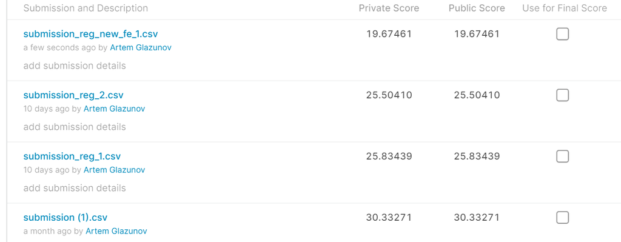

Видно, что новое признаковое описание существенно улучшило качество регрессии, при этом прогнозы предыдущих недель не понадобились, более того, они даже ухудшали качество. Основными признаками в соответствии с feature_importances являются сами временные ряды, их значения за 24 часа и за неделю до прогноза, а также их произведения с другими признаками. Также полезными оказались некоторые бинарные географические признаки и временные признаки.

Таким образом, за 30 минут обучения удалось получить достойное качество при обучении на 3 месяцах. Такой подход кажется перспективным, при этом основные признаки, влияющие на качество, получить можно очень быстро. При этом в нем есть один минус: в данных все зоны перемешаны, и их приходится отделять с помощью признаков. Возможно, это негативно сказывается на качестве.

На следующей неделе будет рассмотрен вариант построения 600 малых моделей, по 6 моделей для каждой зоны.